# 第4章 非遵守者

[R4.2] 両側非遵守者

作成者：川口康平

最終更新: 2024-09-15

ここでは、第4章の4.3節「両側非遵守者」のケースにおける処置割当効果と局所平均処置効果の推定方法を実装する。 `CausalInferenceTextbook`から呼び出している関数は`R/functions_noncompliance.R`に定義されている。まず標本の潜在結果を生成し、次に、処置ベクトルと顕在結果を生成する。このとき、遵守タイプごとに平均処置効果が異なる状況を考える。その実現した処置割当ベクトル、処置受取ベクトルと顕在結果をもとに、処置受取と結果の処置割当効果を推定する。次に、それらの推定値をもちいて、局所平均処置効果を推定する。

両側非遵守者のケースでは局所平均処置効果を推定するためには反抗者の非存在が必要である。この点について確認するために、反抗者が存在するデータと存在しないデータを生成し、推定結果を比較する。

# 1 シミュレーションデータの生成

## 1.1 定数とパラメータの設定

```r
set.seed(1)
N <- 1000
N_1 <- 500
G <-
  c(
    "nt",
    "co",
    "at",
    "df"
  )
```

つぎに、母集団における平均処置効果`tau_population`を設定する。

```r
tau_population <-
  c(
    1,
    2,
    3,
    4
  )
```

## 1.2 データの生成

以上の定数とパラメーターを元に標本の潜在結果を生成する。この操作が一回の無作為抽出にあたる。無作為抽出された標本における平均処置効果`tau`も計算する。遵守タイプは`g`であらわされる。

```r
outcome_potential <-
  1:length(G) %>%
  purrr::map(
    function (n) {
      df <-
        tibble::tibble(
          g = G[n],
          y_0 =
            rnorm(
              N / length(G),
              mean = 0,
              sd = 1
            ),
          y_1 =
            rnorm(
              N / length(G),
              mean = tau_population[n],
              sd = 1
            )
        )
      return(df)
    }
  ) %>%
  dplyr::bind_rows()

tau <-
  outcome_potential %>%
  dplyr::group_by(g) %>%
  dplyr::summarise(
    tau =
      mean(
        y_1 - y_0
      )
  ) %>%
  dplyr::ungroup()

outcome_potential %>%
  head() %>%
  kbl() %>%
  kable_styling()
```

| g | y_0 | y_1 |
| --- | --- | --- |
| nt | -0.6264538 | 1.1362219 |
| nt | 0.1836433 | 1.4071676 |
| nt | -0.8356286 | 0.9303452 |
| nt | 1.5952808 | 0.7523357 |
| nt | 0.3295078 | 1.6955508 |
| nt | -0.8204684 | 2.1462284 |

```r
outcome_potential %>%
  modelsummary::datasummary_skim()
```

Unique

Missing Pct.

Mean

SD

Min

Median

Max

Histogram

y_0

1000

0

0.0

1.0

-3.2

-0.1

3.2

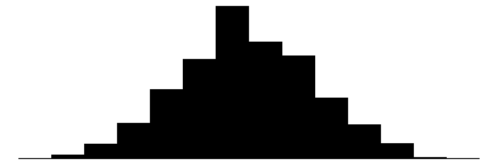

y_1

1000

0

2.5

1.5

-2.0

2.5

6.9

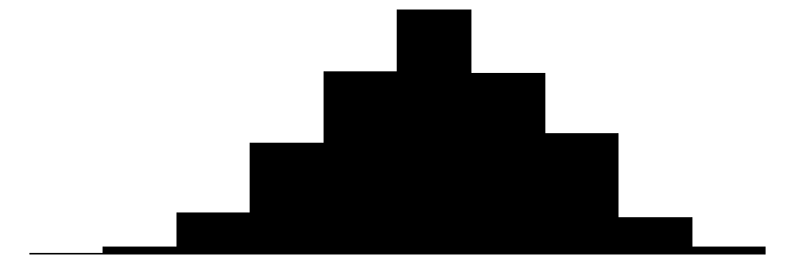

g

N

%

at

250

25.0

co

250

25.0

df

250

25.0

nt

250

25.0

```r
tau %>%
  kbl() %>%
  kable_styling()
```

| g | tau |
| --- | --- |
| at | 3.089228 |
| co | 2.089579 |
| df | 3.987363 |
| nt | 1.000949 |

さて、この設定では反抗者が存在する。以下の分析で見るように、このデータでは平均処置効果はうまく推定できない。そこで、反逆者が存在しないデータも生成しよう。

```r
outcome_potential_nodefier <-
  outcome_potential %>%
  dplyr::filter(g != "df")
```

次に、観察されるデータを生成する。そのために、まず処置割当ベクトル`z`を生成する。この処置割当ベクトルと遵守タイプにもとづいて、処置受取ベクトル`d`を生成する。この操作が一回の無作為化実験にあたる。実現したデータには遵守タイプ`g`は含まれないことに注意しよう。反抗者が含まれるデータと含まれないデータをそれぞれ用意する。

```r
data_realized <-
  generate_data_noncompliance_twoside(
    outcome_potential = outcome_potential,
    N_1 = N_1,
    seed = 1
  )
data_realized %>%
  head() %>%
  kbl() %>%
  kable_styling()
```

| z | d | y |
| --- | --- | --- |
| 1 | 0 | -0.6264538 |
| 0 | 0 | 0.1836433 |
| 1 | 0 | -0.8356286 |
| 0 | 0 | 1.5952808 |
| 1 | 0 | 0.3295078 |
| 0 | 0 | -0.8204684 |

```r
data_realized %>%
  modelsummary::datasummary_skim()
```

Unique

Missing Pct.

Mean

SD

Min

Median

Max

Histogram

z

2

0

0.5

0.5

0.0

0.5

1.0

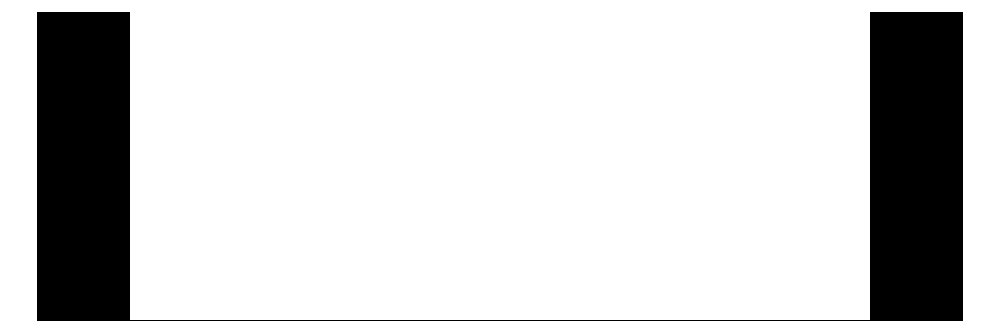

d

2

0

0.5

0.5

0.0

0.0

1.0

[figure not shown]

y

1000

0

1.5

1.9

-3.0

1.4

6.6

[figure not shown]

```r
data_realized_nodefier <-
  generate_data_noncompliance_twoside(
    outcome_potential = outcome_potential_nodefier,
    N_1 = N_1,
    seed = 1
  )
data_realized_nodefier %>%
  head() %>%
  kbl() %>%
  kable_styling()
```

| z | d | y |
| --- | --- | --- |
| 1 | 0 | -0.6264538 |
| 1 | 0 | 0.1836433 |
| 1 | 0 | -0.8356286 |
| 1 | 0 | 1.5952808 |
| 1 | 0 | 0.3295078 |
| 0 | 0 | -0.8204684 |

```r
data_realized_nodefier %>%
  modelsummary::datasummary_skim()
```

Unique

Missing Pct.

Mean

SD

Min

Median

Max

Histogram

z

2

0

0.7

0.5

0.0

1.0

1.0

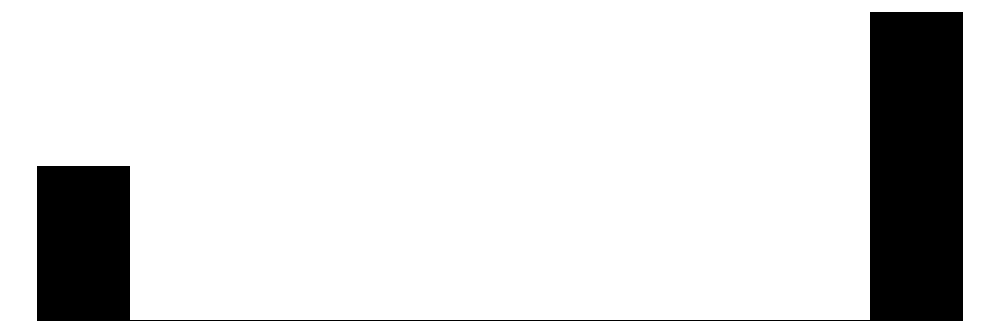

d

2

0

0.6

0.5

0.0

1.0

1.0

[figure not shown]

y

750

0

1.5

1.7

-2.9

1.6

6.6

[figure not shown]

# 2 分析

## 2.1 $\tilde{\tau}_D$の手計算

観察されたデータにもとづいて、処置が割り当てられた時と割り当てられていない時の処置の受取確率の差を計算する。これが処置受取の処置割当効果$\tilde{\tau}_D$の推定値となる。

```r
tau_tilde_d <-
  data_realized %>%
  dplyr::summarise(
       d =
        sum(d * z) / sum(z) -
        sum(d * (1 - z)) / sum(1 - z)
    ) %>%
  dplyr::pull(d)
tau_tilde_d
```

```
## [1] 0.012
```

このように、defierがいるケースでは、$\tilde{\tau}_D$の値はcomplierのシェア (0.25)とは大きく異なっている。

```r
tau_tilde_d_nodefier <-
  data_realized_nodefier %>%
  dplyr::summarise(
    d =
      sum(d * z) / sum(z) -
      sum(d * (1 - z)) / sum(1 - z)
  ) %>%
  dplyr::pull(d)
tau_tilde_d_nodefier
```

```
## [1] 0.36
```

## 2.2 回帰分析による$\tilde{\tau}_D$の推定

同値な推定量が回帰分析によって得られる。

```r
data_realized %>%
  lm(
    data = .,
    formula = d ~ z
  ) %>%
  modelsummary::modelsummary(
    fmt = 6
  )
```

|  | (1) |
| --- | --- |
| (Intercept) | 0.488000 |
|  | (0.022380) |
| z | 0.012000 |
|  | (0.031650) |
| Num.Obs. | 1000 |
| R2 | 0.000 |
| R2 Adj. | -0.001 |
| AIC | 1457.3 |
| BIC | 1472.0 |
| Log.Lik. | -725.647 |
| RMSE | 0.50 |

```r
data_realized_nodefier %>%
  lm(
    data = .,
    formula = d ~ z
  ) %>%
  modelsummary::modelsummary(
    fmt = 6
  )
```

|  | (1) |
| --- | --- |
| (Intercept) | 0.324000 |
|  | (0.029508) |
| z | 0.360000 |
|  | (0.036140) |
| Num.Obs. | 750 |
| R2 | 0.117 |
| R2 Adj. | 0.116 |
| AIC | 988.9 |
| BIC | 1002.7 |
| Log.Lik. | -491.437 |
| RMSE | 0.47 |

## 2.3 $\tilde{\tau}_Y$の手計算

観察されたデータにもとづいて、結果の平均の差を計算する。これが結果の処置割当効果$\tilde{\tau}_Y$の推定値となる。

```r
tau_tilde_y <-
  data_realized %>%
  dplyr::summarise(
    y =
    sum(y * z) / sum(z) -
    sum(y * (1 - z)) / sum(1 - z)
  ) %>%
  dplyr::pull(y)
tau_tilde_y
```

```
## [1] -0.3015367
```

```r
tau_tilde_y_nodefier <-
  data_realized_nodefier %>%
  dplyr::summarise(
    y =
      sum(y * z) / sum(z) -
      sum(y * (1 - z)) / sum(1 - z)
  ) %>%
  dplyr::pull(y)
tau_tilde_y_nodefier
```

```
## [1] 0.7682759
```

## 2.4 回帰分析による$\tilde{\tau}_Y$の推定

同値な推定量が回帰分析によって得られる。

```r
data_realized %>%
  lm(
    data = .,
    formula = y ~ z
  ) %>%
  modelsummary::modelsummary(
    fmt = 6
  )
```

|  | (1) |
| --- | --- |
| (Intercept) | 1.611265 |
|  | (0.082581) |
| z | -0.301537 |
|  | (0.116787) |
| Num.Obs. | 1000 |
| R2 | 0.007 |
| R2 Adj. | 0.006 |
| AIC | 4068.5 |
| BIC | 4083.3 |
| Log.Lik. | -2031.266 |
| RMSE | 1.84 |

```r
data_realized_nodefier %>%
  lm(
    data = .,
    formula = y ~ z
  ) %>%
  modelsummary::modelsummary(
    fmt = 6
  )
```

|  | (1) |
| --- | --- |
| (Intercept) | 0.947737 |
|  | (0.104576) |
| z | 0.768276 |
|  | (0.128079) |
| Num.Obs. | 750 |
| R2 | 0.046 |
| R2 Adj. | 0.045 |
| AIC | 2886.7 |
| BIC | 2900.6 |
| Log.Lik. | -1440.372 |
| RMSE | 1.65 |

## 2.5 $\tilde{\tau}_{Y, co} = \tau_{late}$の手計算

次に、結果の処置割当効果を処置受取の処置割当効果で割ることによって局所平均処置効果の推定値を得る。

```r
tau_late <-
  tau_tilde_y /
  tau_tilde_d
tau_late
```

```
## [1] -25.12806
```

このように、defierがいるケースでは、$\tilde{\tau}_{Y, co}$の値はcomplierの平均処置効果 (2)とは大きく異なる値になる。

```r
tau_late_nodefier <-
  tau_tilde_y_nodefier /
  tau_tilde_d_nodefier
tau_late_nodefier
```

```
## [1] 2.1341
```

一方、defierがいないケースでは、$\tilde{\tau}_{Y, co}$の値はcomplierの平均処置効果 (2)と近い値になる。

## 2.6 二段階最小二乗法による$\tilde{\tau}_{Y, co} = \tau_{late}$の推定

```r
data_realized %>%
  estimatr::iv_robust(
    data = .,
    formula = y ~ d | z
  ) %>%
  modelsummary::modelsummary(
    fmt = 6
  )
```

|  | (1) |
| --- | --- |
| (Intercept) | 13.873759 |
|  | (36.733916) |
| d | -25.128061 |
|  | (74.326741) |
| Num.Obs. | 1000 |
| R2 | -56.939 |
| R2 Adj. | -56.997 |

```r
data_realized_nodefier %>%
  estimatr::iv_robust(
    data = .,
    formula = y ~ d | z
  ) %>%
  modelsummary::modelsummary(
    fmt = 6
  )
```

|  | (1) |
| --- | --- |
| (Intercept) | 0.256288 |
|  | (0.142297) |
| d | 2.134100 |
|  | (0.239793) |
| Num.Obs. | 750 |
| R2 | 0.576 |
| R2 Adj. | 0.575 |